# Rainfall and roof shape

Mark Dingemanse (MPI for Psycholinguistics)

# Objectives

1. Play with the new D-PLACE database
2. Test a hunch about the relation of roof shape to rainfall (briefly, lots of rain negatively selects against flat roofs). Somewhat trivial, but easy to check, lots of data, and fieldwork experience in Ghana provides relevant ethnographic and historical background (including a possible account for an apparent exception).
3. Do this while controlling for language family (Galton’s problem) and region (horizontal diffusion)

# Preliminaries

Clear workspace, check for /in/ and /out/ directories (create them if needed), and load packages (install them if needed)

```r
rm(list=ls())
add_working_dir <- function(x) { if(file.exists(x)) { cat(x,"dir:",paste0(getwd(),"/",x,"/")) } else { dir.create(paste0(getwd(),"/",x))
  cat("subdirectory",x,"created in",getwd()) } }
add_working_dir("in")
add_working_dir("out")

list.of.packages <- c("ggplot2","tidyr","dplyr","ggthemes","lme4","extremevalues","mapproj","sp","rgeos")
new.packages <- list.of.packages[!(list.of.packages %in% installed.packages()[,"Package"])]
if(length(new.packages)>0) install.packages(new.packages)
lapply(list.of.packages, require, character.only=T)
```

```
## rgeos version: 0.3-23, (SVN revision 546)
##  GEOS runtime version: 3.5.0-CAPI-1.9.0 r4084
##  Linking to sp version: 1.2-5
##  Polygon checking: TRUE
```

```r
rm(list.of.packages,new.packages)
```

# Hypothesis

Main hunch: Roof type is related to precipitation such that round/sloping roofs more likely when there is much rain. Note the directionality: we expect few flat roofs in high rainfall societies, but we have no predictions for what happens in low rainfall societies. In causal terms, high rainfall selects *against* flat roofs, but low rainfall does not select *for* them.

# Data

Load and pre-process D-PLACE data. Attribution:

> Research that uses data from D-PLACE should cite both the original source(s) of the data and the paper by Kirby et al. in which D-PLACE was first presented (e.g., research using cultural data from the Binford Hunter-Gatherer dataset: “”Binford (2001); Binford and Johnson (2006); Kirby et al. 2016)." The reference list should include the date data were accessed and URL for D-PLACE (https://d-place.org), in addition to the full references for Binford (2001), Binford and Johnson (2006), and Kirby et al. (2016)."

```r
# Here's a direct link to the query on D-PLACE
# https://d-place.org/societies?c=%5B%7B%22variable%22:83,%22id%22:654%7D,%7B%22variable%22:83,%22id%22:655%7D,%7B%22variable%22:83,%22id%22:656%7D,%7B%22variable%22:83,%22id%22:657%7D,%7B%22variable%22:83,%22id%22:658%7D,%7B%22variable%22:83,%22id%22:659%7D,%7B%22variable%22:83,%22id%22:660%7D,%7B%22variable%22:83,%22id%22:661%7D,%7B%22variable%22:83,%22id%22:662%7D%5D&p=%5B1,2,3,4,5,6,7,8,9,10,11,12,13,15,16,17,18,19,20,21,22,23,24,25,26,27,28,29,30,31,32,33,34,35,36,37,38,39,40,41,42,43,44,45,46,47,48,49,50,51%5D&e=%5B%5B3,%22inrange%22,%5B%220.9970%22,%22547.9482%22%5D%5D%5D

# Load data (skipping line 1, which is a note about attribution)

d <- read.csv(file="in/dplace-export.csv",skip=1)

# Rename unwieldy variable names
names(d)[names(d)=="Description..EA082.House.construction..shape.of.roof"] <- "roofdesc"
names(d)[names(d)=="Code..EA082.House.construction..shape.of.roof"] <- "roofcode"
names(d)[names(d)=="Variable..Monthly.Mean.Precipitation..mm."] <- "rainfall"
names(d)[names(d)=="Code..EA087.House.construction..secondary.house.type...shape.of.roof"] <- "roofcode.secondary"
names(d)[names(d)=="Revised.longitude"] <- "longitude"
names(d)[names(d)=="Revised.latitude"] <- "latitude"
names(d)[names(d)=="References..EA082.House.construction..shape.of.roof"] <- "references"
names(d)[names(d)=="Region.name"] <- "region"

# What's the mapping exactly?
code <- unique(d$roofcode)
desc <- unique(d$roofdesc)
roofs <- data.frame(code,desc)

# make summary variable flatroof, 1 for flat, 0 for non-flat
# we have only 95 societies with flat roofs and 1035 with non-flat
d$flatroof <- ifelse(d$roofcode == 7,1,0) # i.e. flatroof = 1 if roofcode 7, 0 otherwise
d$flatroof <- as.factor(d$flatroof)
xtabs(~ flatroof,data=d)
```

```
## flatroof
##    0    1
## 1035   95
```

(There is also a bit of data for roof shape of secondary buildings, but it only covers 30% of the dataset and the biases hypothesised here are more important for main dwellings so we won’t use it here.)

# First exploration

```r
d %>%
  group_by(flatroof) %>%
  summarise(mean=mean(rainfall))
```

```
## # A tibble: 2 x 2
##   flatroof      mean
##     <fctr>     <dbl>
## 1        0 105.82755
## 2        1  48.10644
```

## Extreme values

What are the extreme values? `getOutliers()` computes extreme values against a baseline expectation of a normal distribution

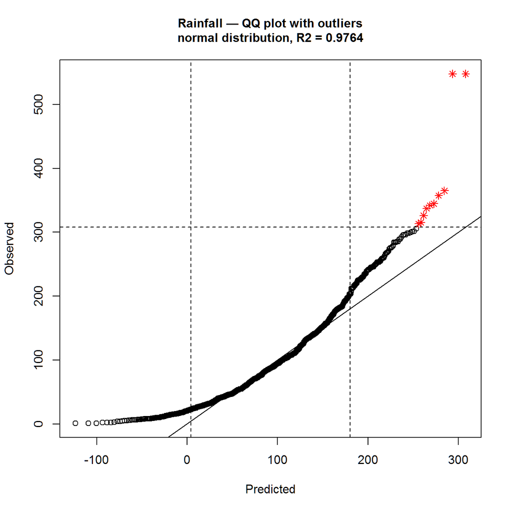

```r
d.outliers <- getOutliers(d$rainfall)
outlierPlot(d$rainfall, d.outliers, title="Rainfall — QQ plot with outliers\nnormal distribution, R2 = 0.9764")
```

That QQ plot based on a normal distribution doesn’t look optimal: two extreme values are classified as outliers, together with the tail end of what looks like a continuous distribution. Can we do better?

Well, precipitation is probably better modelled using a Weibull distribution: after all, 0 is a hard minimum whereas there is more room for variation on the other end (cf. Wilks 1989).

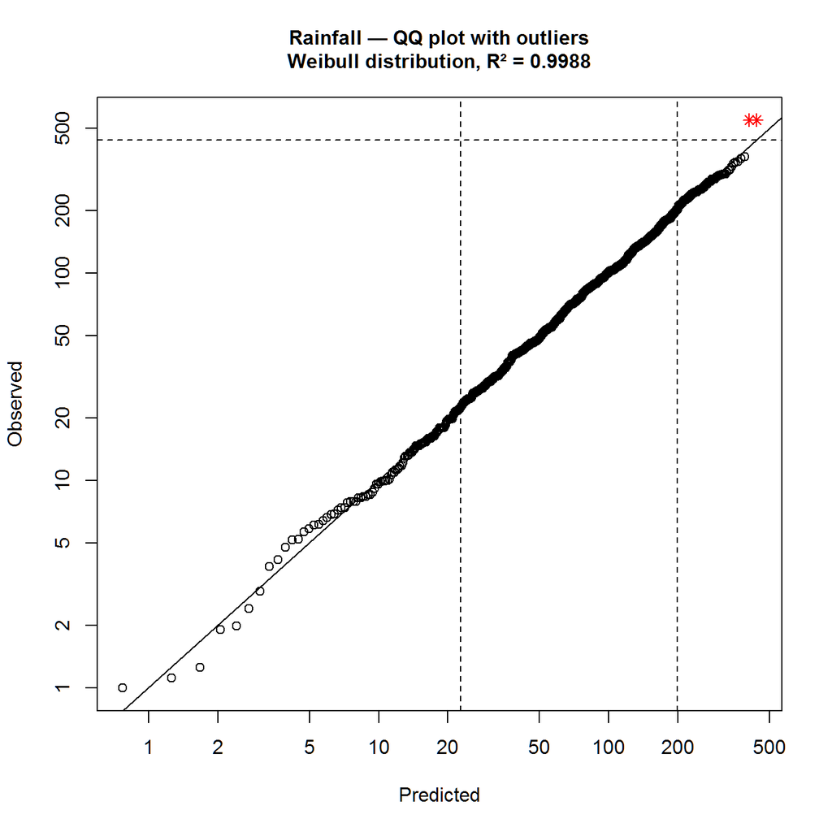

```r
d.outliers.weibull <- getOutliers(d$rainfall,distribution="weibull")
outlierPlot(d$rainfall, d.outliers.weibull, title="Rainfall — QQ plot with outliers\nWeibull distribution, R² = 0.9988")
```

Whoah, that’s a pretty tight fit — R² = 0.9988!

Side note: we can also plot this in ggplot2 of course — though I’m not sure how to compute the dparams for qweibull so I’ve just taken them from `d.outliers.weibull`

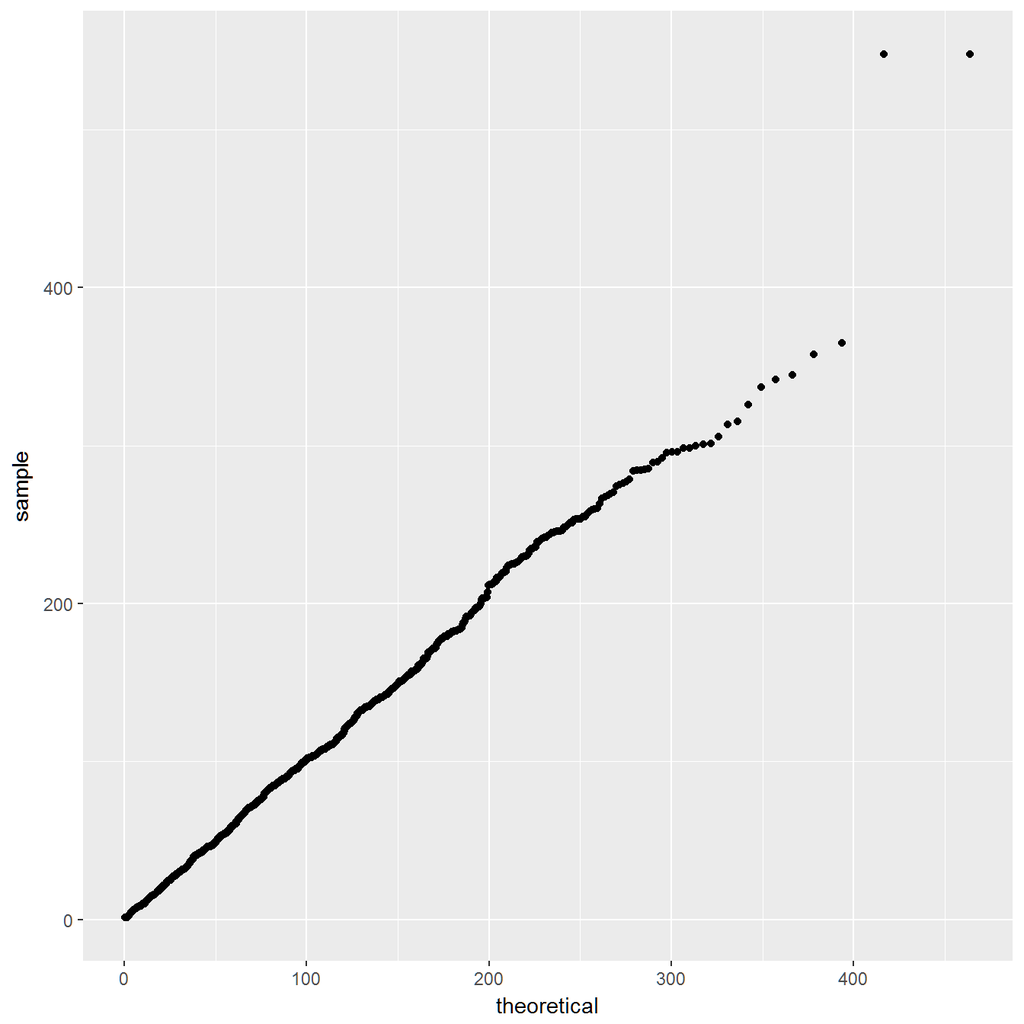

```r
ggplot(d,aes(sample=rainfall)) +
  stat_qq(distribution=qweibull,dparams = list(shape=1.42, scale=110))
```

The nice thing about ggplot is that it’s trivial to group by flatroof (0/1), which already suggests different distributions

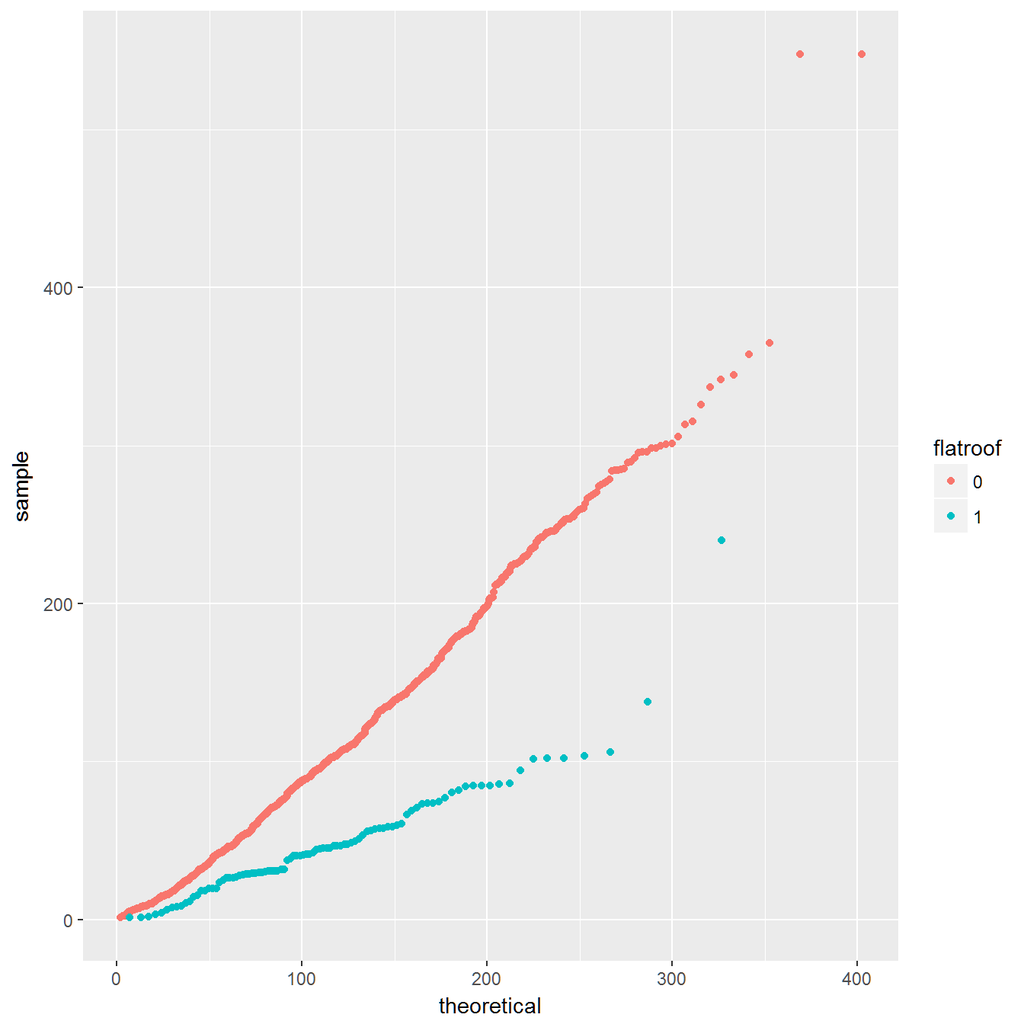

```r
ggplot(d,aes(sample=rainfall,colour=flatroof)) +
  stat_qq(distribution=qweibull,dparams = list(shape=1.8, scale=130))
```

So what are the most extreme values? Both are on the right, and both are in roughly the same location: Saipan Island.

```r
d.outliers.weibull$nOut # both are on the right
```

```
##  Left Right
##     0     2
```

```r
d[c(d.outliers.weibull$iRight),c("Preferred.society.name","rainfall","latitude","longitude")]
```

```
##     Preferred.society.name rainfall latitude longitude
## 19                Chamorro 547.9482    15.13    145.71
## 135            Carolinians 547.9482    15.21    145.76
```

Monthly rainfall for both is recorded as 547.9482, probably taken or interpolated from the same weather station(s). The lat/long places both on Saipan Island. Annual rainfall there is highly variable, but ranges from 1900mm to 2300mm, i.e. 158-192 monthly, according to a 2004 report [1]. That is still roughly twice as high as the median, but at least it’s not six times as high. It is hard to find sources with historical precipitation data for the focal years of the Ethnographic Atlas (1930-1950), but I consider this enough reason to treat these data points as quirks to be excluded.

[1] http://www.weriguam.org/reports/item/rainfall-climatology-for-saipan-distribution-return-periods-el-nino-tropical-cyclones-and-long-term-variations.html

We create a copy of the data that excludes these extreme outliers and do the Weibull plot again as a sanity check.

```r
d.no <- d[-d.outliers.weibull$iRight,]

d.no.outliers <- getOutliers(d.no$rainfall,distribution="weibull")
d.no.outliers$nOut # now there are no outliers anymore
```

```
##  Left Right
##     0     0
```

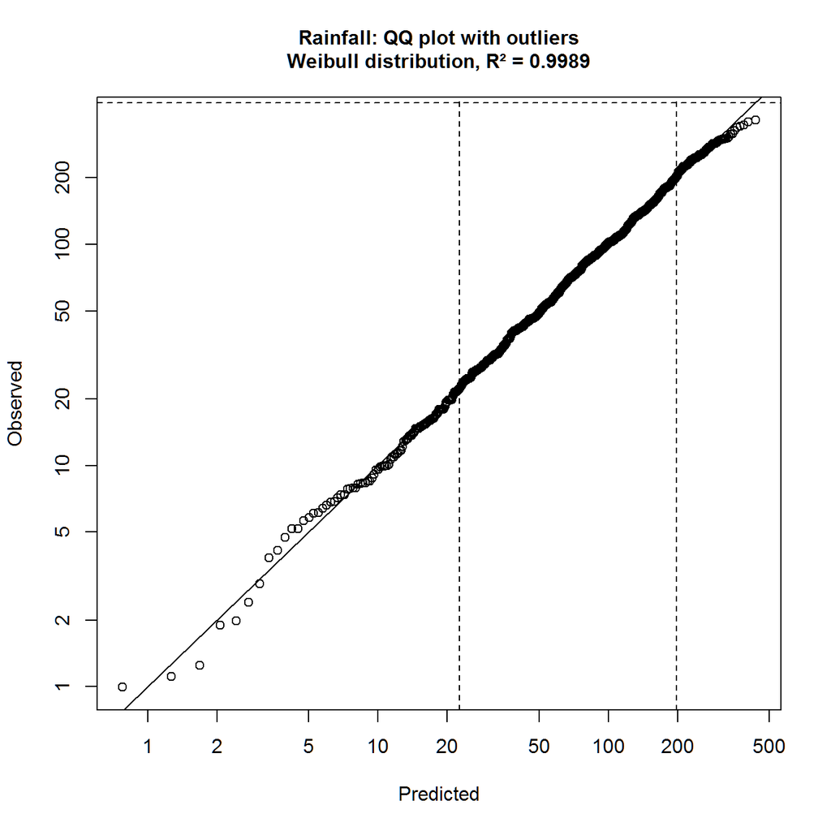

```r
outlierPlot(d.no$rainfall, d.no.outliers,title="Rainfall: QQ plot with outliers\nWeibull distribution, R² = 0.9989")
```

```r
d.no %>%
  group_by(flatroof) %>%
  summarise(count=n(),mean=mean(rainfall))
```

```
## # A tibble: 2 x 3
##   flatroof count      mean
##     <fctr> <int>     <dbl>
## 1        0  1033 104.97156
## 2        1    95  48.10644
```

```r
t.test(d.no[which(d.no$flatroof==0),"rainfall"],d.no[which(d.no$flatroof==1),"rainfall"])
```

```
##
##  Welch Two Sample t-test
##
## data:  d.no[which(d.no$flatroof == 0), "rainfall"] and d.no[which(d.no$flatroof == 1), "rainfall"]
## t = 13.572, df = 178.13, p-value < 2.2e-16
## alternative hypothesis: true difference in means is not equal to 0
## 95 percent confidence interval:
##  48.59708 65.13317
## sample estimates:
## mean of x mean of y
## 104.97156  48.10644
```

So what are the 3 societies with the highest rainfall in the flat roof category?

```r
top3 <- d.no %>%
  filter(flatroof == 1) %>%     # filter for flat roofs
  arrange(desc(rainfall)) %>%   # arrange to sort by rainfall
  slice(1:3)                    # slice to take the first 3 rows
top3[,c("Preferred.society.name","region","rainfall","roofdesc","references")]
```

```
## # A tibble: 3 x 5
##   Preferred.society.name               region rainfall           roofdesc
##                   <fctr>               <fctr>    <dbl>             <fctr>
## 1             Anak Dalam              Malesia 239.9378 Flat or horizontal
## 2                Chugach    Subarctic America 137.5110 Flat or horizontal
## 3                   Buem West Tropical Africa 105.9047 Flat or horizontal
## # ... with 1 more variables: references <fctr>
```

# Visualising

## Plotting

Basic plots

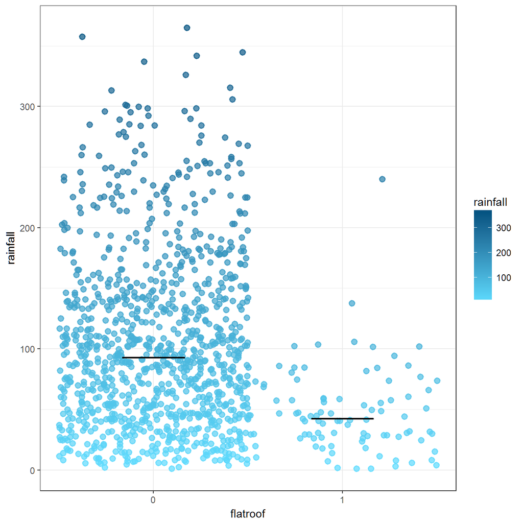

```r
myseed=100
set.seed(myseed)
ggplot(d.no, aes(x=flatroof,y=rainfall,fill=rainfall,colour=rainfall)) +
  theme_bw() +
  geom_jitter(alpha=0.7,shape=21,width=0.5,size=2,stroke=1) +
  scale_fill_gradient("rainfall", low="#5edcff", high="#035280") +
  scale_colour_gradient("rainfall", low="#5edcff", high="#035280") +
  stat_summary(fun.y = "median", fun.ymin = "median", fun.ymax= "median", size=0.3,width=0.33, geom = "crossbar")
```

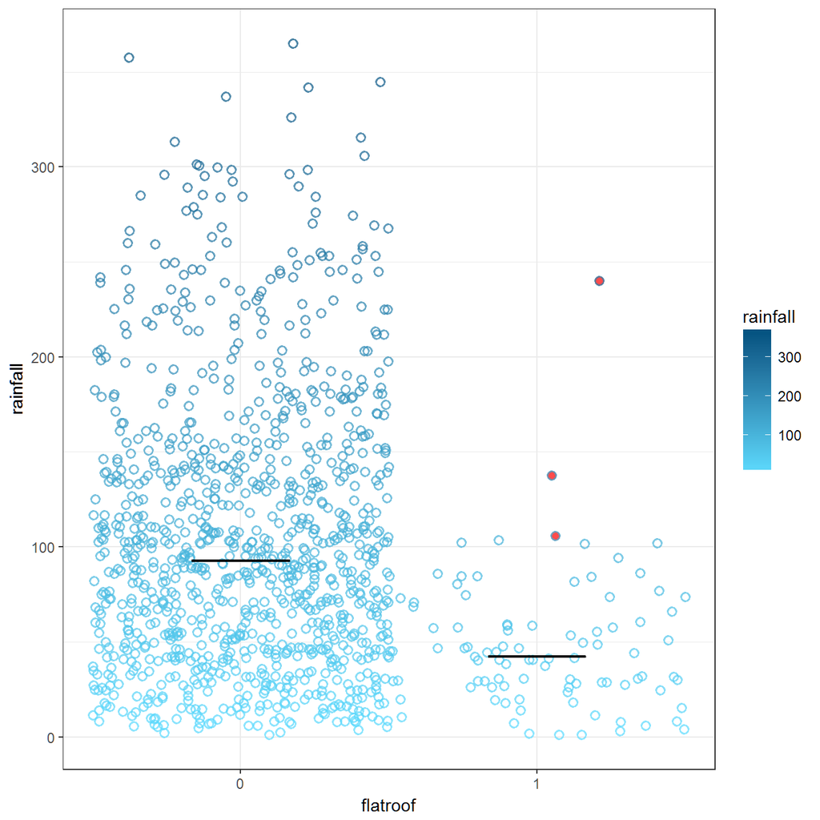

```r
ggsave(file="out/rainfall-by-rooftype.png", width=3,height=5)

# Highlight highest 3
d.no$top3 <- ifelse(d.no$Preferred.society.name %in% top3$Preferred.society.name, 1, NA)
d.no$top3 <- as.factor(d.no$top3)

set.seed(myseed)
ggplot(d.no, aes(x=flatroof,y=rainfall,fill=top3,colour=rainfall)) +
  theme_bw() +
  geom_jitter(alpha=0.7,shape=21,width=0.5,size=2,stroke=1) +
  scale_colour_gradient("rainfall", low="#5edcff", high="#035280") +
  scale_fill_manual(values=c("red"), guide = FALSE) +
  stat_summary(aes(x=flatroof,y=rainfall),inherit.aes=F,fun.y = "median", fun.ymin = "median", fun.ymax= "median", size=0.3,width=0.33, geom = "crossbar")
```

```r
 ggsave(file="out/rainfall-by-rooftype-top3.png", width=3,height=5)
```

## Maps

Maps confirm that flat roofs predominantly occur in drier places.

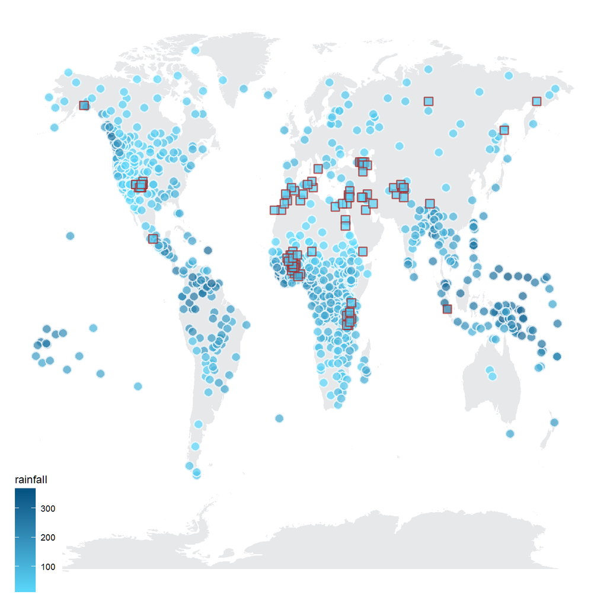

```r
ggplot(d.no,aes(longitude,latitude)) +
  theme_map() +
  borders("world", colour=NA, fill="#e7e8ea") +
  geom_point(data=filter(d.no,flatroof==0),aes(fill=rainfall,colour=flatroof),size=3,shape=21,stroke=1,alpha=0.7) +
  geom_point(data=filter(d.no,flatroof==1),aes(fill=rainfall,colour=flatroof),size=3,shape=22,stroke=1,alpha=0.7) +
  scale_colour_manual(values = c("#ffffff","brown"), guide = FALSE) +
  scale_fill_gradient("rainfall", low="#5edcff", high="#035280")
```

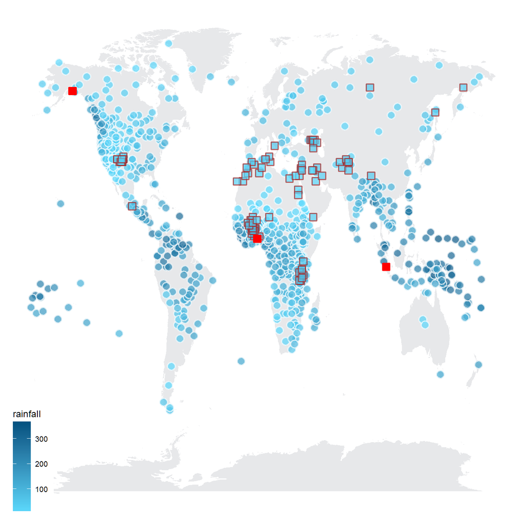

```r
ggsave(file="out/map-rainfall-by-rooftype.png", width=12,height=8)

# map highest
last_plot() + geom_point(data=top3,aes(longitude,latitude),fill="red",colour="red",size=3,shape=22,stroke=1)
```

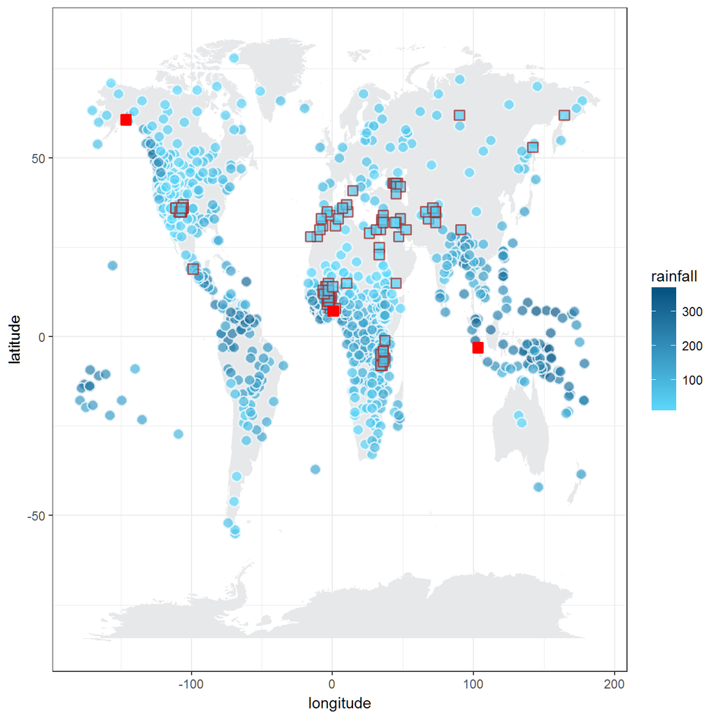

```r
ggsave(file="out/map-rainfall-by-rooftype-highest.png", width=12,height=8)

# zoom: West Africa
last_plot() + theme_bw() # use to target desired lat/long for zooming
```

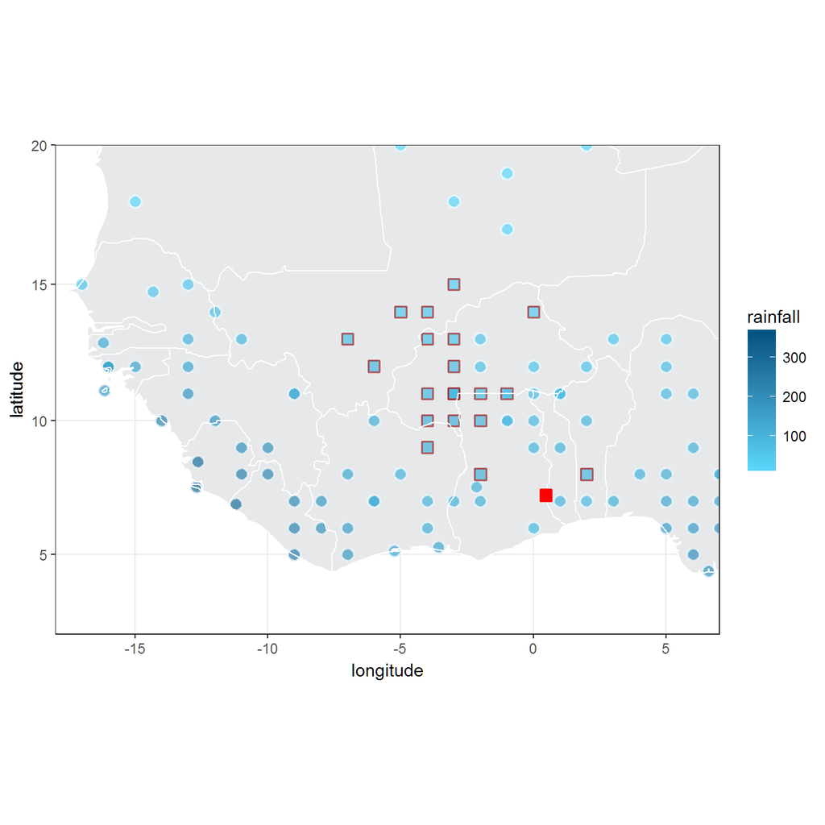

```r
zoom1 <- last_plot() + borders(colour="white") + coord_map(xlim = c(-18,7), ylim = c(20,2))

zoom1 + geom_point(data=top3,aes(longitude,latitude),fill="red",colour="red",size=3,shape=22,stroke=1)
```

```r
ggsave(file="out/map-rainfall-by-rooftype-west-africa.png", width=12,height=8)
```

# Statistical modelling

So the difference in means and in distributions is suggestive. But not all observations are independent. For one thing, some languages are from the same language family and so may have inherited cultural features from a common ancestor. We use generalised linear mixed effects modelling to control for this. We add language family as a random intercept (meaning we allow the value of roof to be ‘dependent’ to some degree on language family).

We create two models: one in which we try to predict flatroof by language family alone, another where add rainfall as a fixed effect. The second one is what we’re primarily interested in. Comparing them, the one including rainfall as a fixed effect, in # addition to language family, explains the spread of data significantly better (χ2(1) = 51.331, p < 0.00001, log likelihood difference 25.67).

```r
model1 <- glmer(flatroof ~ (1|Language.family), data=d.no,family=binomial)
summary(model1)
```

```
## Generalized linear mixed model fit by maximum likelihood (Laplace
##   Approximation) [glmerMod]
##  Family: binomial  ( logit )
## Formula: flatroof ~ (1 | Language.family)
##    Data: d.no
##
##      AIC      BIC   logLik deviance df.resid
##    536.9    547.0   -266.5    532.9     1126
##
## Scaled residuals:
##     Min      1Q  Median      3Q     Max
## -2.2675 -0.2849 -0.1048 -0.0136  9.5412
##
## Random effects:
##  Groups          Name        Variance Std.Dev.
##  Language.family (Intercept) 72.31    8.504
## Number of obs: 1128, groups:  Language.family, 158
##
## Fixed effects:
##             Estimate Std. Error z value Pr(>|z|)
## (Intercept)   -8.468      1.284  -6.596 4.22e-11 ***
## ---
## Signif. codes:  0 '***' 0.001 '**' 0.01 '*' 0.05 '.' 0.1 ' ' 1
```

```r
model2 <- glmer(flatroof ~ rainfall + (1|Language.family), data=d.no,family=binomial)
summary(model2)
```

```
## Generalized linear mixed model fit by maximum likelihood (Laplace
##   Approximation) [glmerMod]
##  Family: binomial  ( logit )
## Formula: flatroof ~ rainfall + (1 | Language.family)
##    Data: d.no
##
##      AIC      BIC   logLik deviance df.resid
##    487.6    502.7   -240.8    481.6     1125
##
## Scaled residuals:
##     Min      1Q  Median      3Q     Max
## -1.7494 -0.2333 -0.0529 -0.0148 31.5177
##
## Random effects:
##  Groups          Name        Variance Std.Dev.
##  Language.family (Intercept) 41.17    6.416
## Number of obs: 1128, groups:  Language.family, 158
##
## Fixed effects:
##              Estimate Std. Error z value Pr(>|z|)
## (Intercept) -5.356594   1.600211  -3.347 0.000816 ***
## rainfall    -0.028642   0.004758  -6.020 1.74e-09 ***
## ---
## Signif. codes:  0 '***' 0.001 '**' 0.01 '*' 0.05 '.' 0.1 ' ' 1
##
## Correlation of Fixed Effects:
##          (Intr)
## rainfall -0.185
```

```r
comparison <- anova(model1, model2)
comparison[1,4]-comparison[2,4] # log likelihood difference
```

```
## [1] -25.66531
```

But the maps show that some of the flat roofs appear in ‘clumps’. Perhaps horizontal diffusion due to cultural contact can explain part of it. Best way to check this would be to compute distance to nearest flatroof neighbour (relevant code here: https://is.gd/FFLbKH), but the coordinate data in D-PLACE is rounded which makes that measure uninformative in regions with many societies. So let’s use region as a proxy. The reasoning is: if you’re in the same region, chances are you have the same kind of roof, whatever it is (i.e. a random intercept).

We compare model 2 with this new model. The new model, which includes region besides language family, explains the spread of data significantly better (χ2(1) = 56.262, p < 0.00001, log likelihood difference 28.13).

```r
model3 <- glmer(flatroof ~ rainfall + (1|region) + (1|Language.family), data=d.no,family=binomial)
summary(model3)
```

```
## Generalized linear mixed model fit by maximum likelihood (Laplace
##   Approximation) [glmerMod]
##  Family: binomial  ( logit )
## Formula: flatroof ~ rainfall + (1 | region) + (1 | Language.family)
##    Data: d.no
##
##      AIC      BIC   logLik deviance df.resid
##    433.3    453.4   -212.7    425.3     1124
##
## Scaled residuals:
##     Min      1Q  Median      3Q     Max
## -1.6833 -0.1615 -0.0559 -0.0212 16.4699
##
## Random effects:
##  Groups          Name        Variance Std.Dev.
##  Language.family (Intercept) 7.848    2.801
##  region          (Intercept) 8.563    2.926
## Number of obs: 1128, groups:  Language.family, 158; region, 50
##
## Fixed effects:
##              Estimate Std. Error z value Pr(>|z|)
## (Intercept) -3.946466   1.479052  -2.668  0.00762 **
## rainfall    -0.025263   0.005173  -4.884 1.04e-06 ***
## ---
## Signif. codes:  0 '***' 0.001 '**' 0.01 '*' 0.05 '.' 0.1 ' ' 1
##
## Correlation of Fixed Effects:
##          (Intr)
## rainfall -0.232
```

```r
comparison <- anova(model2, model3)
comparison[1,4]-comparison[2,4] # log likelihood difference
```

```
## [1] -28.13118
```

Do we even need rainfall, or are region and language family sufficient to explain the distribution of flat roofs? To find out, we compare a model with just region & language family as random effects (model 4) with a model with rainfall added as a fixed effect (model 3). The fullest model, with rainfall as main predictor and region and language family as additional factors, explains the data significantly better (χ2(1) = 29.704, p < 0.00001, log likelihood difference 14.85).

```r
model4 <- glmer(flatroof ~ (1|region) + (1|Language.family), data=d.no,family=binomial)
summary(model4)
```

```
## Generalized linear mixed model fit by maximum likelihood (Laplace
##   Approximation) [glmerMod]
##  Family: binomial  ( logit )
## Formula: flatroof ~ (1 | region) + (1 | Language.family)
##    Data: d.no
##
##      AIC      BIC   logLik deviance df.resid
##    461.0    476.1   -227.5    455.0     1125
##
## Scaled residuals:
##     Min      1Q  Median      3Q     Max
## -1.3287 -0.1671 -0.0433 -0.0084  6.3584
##
## Random effects:
##  Groups          Name        Variance Std.Dev.
##  Language.family (Intercept) 51.18    7.154
##  region          (Intercept) 14.31    3.784
## Number of obs: 1128, groups:  Language.family, 158; region, 50
##
## Fixed effects:
##             Estimate Std. Error z value Pr(>|z|)
## (Intercept)   -9.304      1.825  -5.097 3.44e-07 ***
## ---
## Signif. codes:  0 '***' 0.001 '**' 0.01 '*' 0.05 '.' 0.1 ' ' 1
```

```r
comparison <- anova(model3, model4)
comparison
```

```
## Data: d.no
## Models:
## model4: flatroof ~ (1 | region) + (1 | Language.family)
## model3: flatroof ~ rainfall + (1 | region) + (1 | Language.family)
##        Df    AIC    BIC  logLik deviance  Chisq Chi Df Pr(>Chisq)
## model4  3 461.02 476.10 -227.51   455.02
## model3  4 433.31 453.43 -212.66   425.31 29.704      1  5.034e-08 ***
## ---
## Signif. codes:  0 '***' 0.001 '**' 0.01 '*' 0.05 '.' 0.1 ' ' 1
```

```r
comparison[1,4]-comparison[2,4] # log likelihood difference
```

```
## [1] -14.8519
```

Footnote: We excluded some extreme values (which turned out to be in the flatroof=0 category). Would including them have made any difference for the results? Nope: the full model (model 6) explains the data significantly better (χ2(1) = 29.734, p < 0.00001, log likelihood difference 14.87). Excluding the extreme values was mainly useful to make the plots a little prettier.

```r
model5 <- glmer(flatroof ~ (1|region) + (1|Language.family), data=d,family=binomial)
model6 <- glmer(flatroof ~ rainfall + (1|region) + (1|Language.family), data=d,family=binomial)
comparison <- anova(model5, model6)
comparison
```

```
## Data: d
## Models:
## model5: flatroof ~ (1 | region) + (1 | Language.family)
## model6: flatroof ~ rainfall + (1 | region) + (1 | Language.family)
##        Df    AIC    BIC  logLik deviance  Chisq Chi Df Pr(>Chisq)
## model5  3 461.05 476.14 -227.52   455.05
## model6  4 433.31 453.43 -212.66   425.31 29.734      1  4.957e-08 ***
## ---
## Signif. codes:  0 '***' 0.001 '**' 0.01 '*' 0.05 '.' 0.1 ' ' 1
```

```r
comparison[1,4]-comparison[2,4] # log likelihood difference
```

```
## [1] -14.86684
```

# Conclusions

In this dataset, rainfall is a strong predictor of roof shape, controlling for language family and region. Flat roofs are unlikely to occur in locales with a lot of precipitation. So the hypothesis is supported: rainfall selects against flat roots.